# Building graphs with Japanese vocabulary and kanji

Mon, 20 Oct 2014

[Japanese](http://flothesof.github.io/tag/japanese.html)

This post is a quick and dirty exploration of an aspect of my Japanese learning. The gist behind it is the following: I use a flashcard software called [Anki](http://ankisrs.net/) to guide my learning. I use two decks for learning Japanese: one contains my vocabulary and is recognition only, while the other contains my kanji cards and forces me to write the Japanese characters and remember their structure.

In this post, I use the data from both decks combined to create a graph of how the information for a given learning day is connected.

# Simple text exploration of the data

```python
# necessary imports
from pylab import *
%matplotlib inline
```

```python
from IPython.html.widgets import interact
```

Firts, let's read the raw text files containing the data from my decks. `jp-kanji` contains the kanji I have reviewed today, while `jp-vocab` contains all the words that I have in my Japanese vocabulary deck.

```python
kanji = genfromtxt('files/kanji.csv', dtype=np.str, usecols=0, delimiter=',')
```

```python
myvocab = genfromtxt('files/jp_vocab.csv', dtype=np.str, usecols=0, delimiter=',')
```

The characters I have read so far are encoded using UTF-8. To work with them, I'm converting them to Python unicode.

```python
from codecs import decode
kanji = [decode(k, 'utf-8') for k in kanji]
myvocab = [decode(w, 'utf-8') for w in myvocab]
```

```python
for k in kanji:
    print k,
```

```
淡 貯 腹 妃 翁 葬 鉄 賀 委 屈 漏 穏 料 庸 累 酌 糾 陵 星 斜 斉 沈 尾 展 雰
```

Let's now write a function that filters my vocabulary list according to whether a given kanji is present in a word or not.

```python
def get_associated_vocab(kanji):
    return filter(lambda s: kanji in s, myvocab)
```

```python
words = get_associated_vocab(kanji[1])
for w in words:
    print w,
```

We can explore this interactively using the IPython notebook tool `interact`:

```python
def print_my_vocab(kanji_char):
    words = get_associated_vocab(kanji_char)
    print "You selected character " + kanji_char
    if len(words) != 0:
        print "Matches in your vocabulary found!"
        for w in words:
            print w
    else:
        print "No match in your vocabulary"
```

```python
interact(lambda ind: print_my_vocab(kanji[ind]),
         ind=(0, len(kanji) - 1))
```

```
You selected character 料
Matches in your vocabulary found!
料理
晩御飯 は 日本 料理 レストランで食べました。おいしかったお好み焼き食べました。<br><br>
材料
小麦粉はケーキの主な材料だ。
食料品
給料
```

```
<function __main__.<lambda>>
```

# Graphical exploration using NetworkX

[NetworkX](http://networkx.github.io/) is a toolkit for the study of networks, written in Python. Inspired by this [example from the gallery](http://networkx.github.io/documentation/latest/examples/drawing/chess_masters.html), we can leverage its graphical tools to visualize the data I have analyzed so far.

My aim here is to make a plot with all the kanji reviewed today and link them to their associated vocabulary.

While writing this post, I encountered some problems with the display of Japanese characters. It turns out that this was due to my `matplotlib` installation and its fonts, that didn't support Japanese characters. I have solved this problem by copying one of my Japanese system fonts within the `matplotlib` fonts directory located, in my case, at *C:\Python27\Lib\site-packages\matplotlib\mpl-data\fonts*. A helpful link in this process was http://stackoverflow.com/questions/23197124/display-non-ascii-japanese-characters-in-pandas-plot-legend.

```python
import networkx as nx
```

Below is a simple test graph that shows how to display a node labelled with a Japanese character.

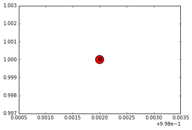

```python
G = nx.Graph()
G.add_node(u"車")
nx.draw_networkx(G, font_family='Aozora Mincho')
```

This being done, we can move on to more serious things. We create our graph with the following code.

```python
import datetime
```

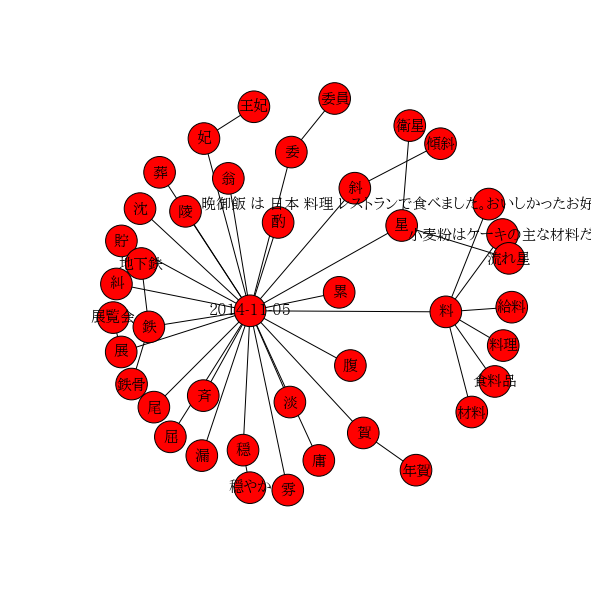

```python
figure(figsize=(10, 10))
G = nx.Graph()
today = datetime.date.today()
G.add_node(today)
for k in kanji:
    G.add_node(k)
    G.add_edge(today, k)
    for expr in get_associated_vocab(k):
        G.add_edge(k, expr)
nx.draw_networkx(G, font_family='Aozora Mincho', font_size=15, node_size=1000)

axis('off');
```

This is quite nice, but we can improve it a little bit by using some coloring, inspired by [this example](http://networkx.github.io/documentation/latest/examples/drawing/ego_graph.html).

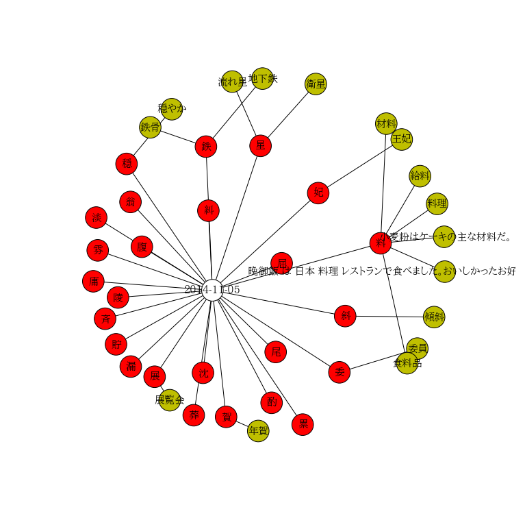

```python
# creating the graph
G = nx.Graph()
today = datetime.date.today()
G.add_node(today)
for k in kanji:
    G.add_node(k)
    G.add_edge(today, k)
    for expr in get_associated_vocab(k):
        G.add_edge(k, expr)

# creating the node colors
node_color = []
for node in G:
    if node == today:
        node_color.append('w')
    elif node in kanji:
        node_color.append('r')
    else:
        node_color.append('y')

# plotting
figure(figsize=(10, 10))
pos = nx.spring_layout(G)
nx.draw(G, pos=pos,
        with_labels=True,
        node_color=node_color,
        font_family='Aozora Mincho', font_size=15,
        node_size=1000)

axis('off');
```

While using visualizations like the one above during the last few days, I have noticed that when there are a lot of words and characters to display, the graph gets messy. Therefore, I'll try to produce a more structured version of the previous graph in the next cells.

The graphical output that we have done above consists of two separate steps. The first step is to compute the node positions in the final graph. The second one is drawing using the previous positions.

In the previous cell, we computed the positions of our nodes using `nx.spring_layout(G)`. The positions computed by the spring algorithm are stored in a dictionary:

```python
pos
```

```
{u'\u5983': array([ 0.63895377,  0.67500245]),
 u'\u6589': array([ 0.03343059,  0.3185518 ]),
 u'\u6599\u7406': array([ 0.97669519,  0.64441187]),
 u'\u6c88': array([ 0.31158778,  0.16515432]),
 u'\u6de1': array([ 0.0082795 ,  0.60559574]),
 u'\u6f0f': array([ 0.10637716,  0.18282049]),
 datetime.date(2014, 11, 5): array([ 0.33843229,  0.39933709]),
 u'\u8caf': array([ 0.06449885,  0.24593801]),
 u'\u6599': array([ 0.81613867,  0.5326309 ]),
 u'\u659c': array([ 0.71547702,  0.32610618]),
 u'\u661f': array([ 0.47509264,  0.80911579]),
 u'\u59d4\u54e1': array([ 0.92043342,  0.23380841]),
 u'\u50be\u659c': array([ 0.96810298,  0.32317835]),
 u'\u6d41\u308c\u661f': array([ 0.39479764,  0.9914399 ]),
 u'\u7d66\u6599': array([ 0.92811008,  0.72305464]),
 u'\u7d2f': array([ 0.59474906,  0.01805415]),
 u'\u5e74\u8cc0': array([ 0.46854098,  0.        ]),
 u'\u5eb8': array([ 0.        ,  0.42477971]),
 u'\u5c3e': array([ 0.51802025,  0.22415128]),
 u'\u7fc1': array([ 0.10560111,  0.64988196]),
 u'\u8cc0': array([ 0.37718882,  0.04015944]),
 u'\u9244': array([ 0.32000005,  0.80690719]),
 u'\u5c48': array([ 0.53514343,  0.47579271]),
 u'\u885b\u661f': array([ 0.63198603,  0.98454265]),
 u'\u914c': array([ 0.5064797 ,  0.07996336]),
 u'\u7a4f': array([ 0.09442873,  0.75785548]),
 u'\u5c55\u89a7\u4f1a': array([ 0.21722116,  0.08730433]),
 u'\u5c55': array([ 0.17416823,  0.15397226]),
 u'\u98df\u6599\u54c1': array([ 0.89176716,  0.19228279]),
 u'\u5730\u4e0b\u9244': array([ 0.48069608,  1.        ]),
 u'\u738b\u5983': array([ 0.8761446 ,  0.82716321]),
 u'\u9244\u9aa8': array([ 0.16174776,  0.86162271]),
 u'\u5c0f\u9ea6\u7c89\u306f\u30b1\u30fc\u30ad\u306e\u4e3b\u306a\u6750\u6599\u3060\u3002': array([ 0.99668281,  0.55111055]),
 u'\u6750\u6599': array([ 0.83223969,  0.87208056]),
 u'\u6669\u5fa1\u98ef \u306f \u65e5\u672c \u6599\u7406 \u30ec\u30b9\u30c8\u30e9\u30f3\u3067\u98df\u3079\u307e\u3057\u305f\u3002\u304a\u3044\u3057\u304b\u3063\u305f\u304a\u597d\u307f\u713c\u304d\u98df\u3079\u307e\u3057\u305f\u3002<br><br>': array([ 0.99848304,  0.45215401]),
 u'\u846c': array([ 0.28533294,  0.0447483 ]),
 u'\u96f0': array([ 0.01251561,  0.51255702]),
 u'\u7a4f\u3084\u304b': array([ 0.22307882,  0.91305033]),
 u'\u9675': array([ 0.07011004,  0.37885549]),
 u'\u8179': array([ 0.13798064,  0.52279467]),
 u'\u7cfe': array([ 0.3268805 ,  0.62509542]),
 u'\u59d4': array([ 0.69909341,  0.16646906])}
```

My plan in the next cells is to compute the positions by myself instead of using the built-in algorithm.

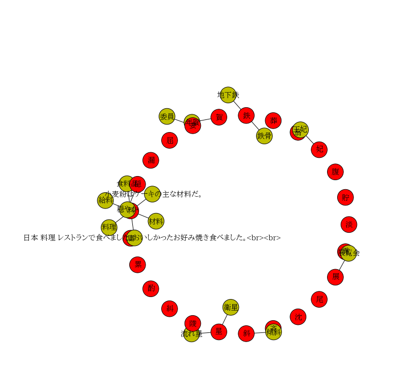

```python
# creating the graph
G = nx.Graph()
today = datetime.date.today()

for k in kanji:
    G.add_node(k)
    for expr in get_associated_vocab(k):
        G.add_edge(k, expr)

# creating the node colors
node_color = []
for node in G:
    if node in kanji:
        node_color.append('r')
    else:
        node_color.append('y')

# computing positions
pos = {}
r1 = 0.3 * len(kanji) / 100.
r2 = r1 / 4.
theta = linspace(0, 2 * pi, len(kanji), endpoint=False)
for ind, k in enumerate(kanji):
    pos[k] = r1 * array([cos(theta[ind]), sin(theta[ind])])
    words = get_associated_vocab(k)
    alpha = linspace(0, 2 * pi, len(words), endpoint=False) + theta[ind] + pi / 4 + (pi / 4) * (ind % 2)
    for ind2, w in enumerate(words):
        if not w in pos:
            pos[w] = r1 * array([cos(theta[ind]), sin(theta[ind])]) + r2 * array([cos(alpha[ind2]), sin(alpha[ind2])])

# plotting
figure(figsize=(10, 10))
nx.draw(G, pos=pos,
        with_labels=True,
        node_color=node_color,
        font_family='Aozora Mincho', font_size=15,
        node_size=1000)

axis('off');
```

This is still not satisfying. So based on the above layout, we will build a small particle simulation. First, we define a particle class that will be able to model repulsive forces, based on its mass, inertia, and spring-like behaviour with a set of "neighbours" to which the particle is linked.

```python
class particle(object):
    def __init__(self, name, pos, fixed=False, mass=1., neighbours=[], stiffness=0.1):
        # inits a particle with a given mass and a given stiffness linkind it to its neighbours
        self.pos = pos
        self.mass = mass
        self.fixed = fixed
        self.neighbours = neighbours
        self.speed = zeros((2))
        self.stiffness = stiffness
        self.name = name
        self.external_force = zeros((2))

    def move(self, dt):
        # moves the particle for a timestep dt
        self.speed += dt/self.mass * self.external_force
        self.pos += self.speed * dt

    def compute_spring_force(self):
        # computes the force exerted upon the node by its neighbours
        force_vector = zeros((2))
        for neighbour in self.neighbours:
            force_vector += self.stiffness * (particles[neighbour].pos - self.pos)
        return force_vector
```

Next, we can code the simulation. First, we build the list of nodes we want to work with.

```python
pos = nx.spring_layout(G)
particles = {}
for k in kanji:
    fixed = True
    neighbours = get_associated_vocab(k)
    particles[k] = particle(k, pos[k], fixed=True, mass=len(neighbours) + 1, neighbours=neighbours)
    for neigh in neighbours:
        particles[neigh] = particle(neigh, pos[neigh], fixed=False, neighbours=[k])
```

```python
def get_pos_dict():
    pos = dict(zip(particles.keys(), [particles[k].pos for k in particles]))
    pos[datetime.date(2014, 11, 5)] = [0., 0.]
    return pos
```

```python
def plot_current_particles():
    figure(figsize=(10, 10))
    nx.draw(G, pos=get_pos_dict(),
        with_labels=True,
        node_color=node_color,
        font_family='Aozora Mincho', font_size=15,
        node_size=1000)
```

Next, we build the iteration steps:

```python
def iterate(dt):
    for current_p in particles:
        external_force = zeros((2))
        for other_p in particles:
            if current_p != other_p:
                # sum repulsive force
                external_force -= particles[other_p].mass / (particles[current_p].pos - particles[other_p].pos) ** 2 * (particles[current_p].pos - particles[other_p].pos)
        external_force += particles[current_p].compute_spring_force()
        particles[current_p].external_force = external_force
    for current_p in particles:
        particles[current_p].move(dt)
```

Let's move this graph.

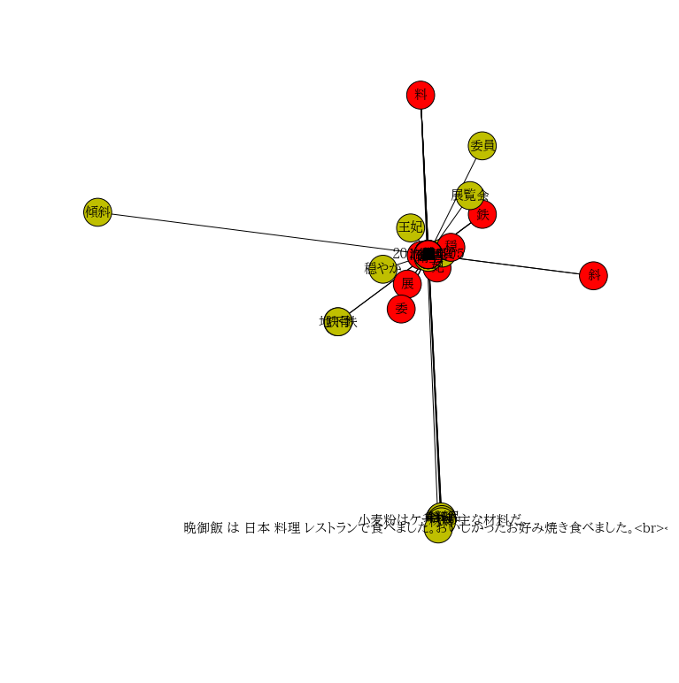

```python
iterate(10)
plot_current_particles()
```

```python
def iterate_and_plot(dt):
    iterate(dt)
    figure(figsize=(10, 10))
    nx.draw(G, pos=get_pos_dict(),
        with_labels=True,
        node_color=node_color,
        font_family='Aozora Mincho', font_size=15,
        node_size=1000)
    axis('off');
```

```python
from IPython.html.widgets import ButtonWidget
from IPython.display import display, clear_output
```

```python
b = ButtonWidget(description="iteration")
display(b)
b.on_click(lambda b: iterate_and_plot(0.1))
```

[output not shown]

[figure not shown]

```python
iterate_and_plot(0.02)
```

```python
particles[u"星"].move(1)
particles[u"星"].pos
```

```
array([             nan,  -1.10393199e+11])
```

```python
pos
```

[output not shown]

This article has been tagged with the following terms:

[Japanese](http://flothesof.github.io/tag/japanese.html)

[figure not shown]